# Sharif University of Technology

## Electrical Engineering Department

[figure not shown]

# Artificial Neural Networks

## HW2

## [Arya Koureshi](https://aryakoureshi.github.io)

## 401204008

### بخش اول : Classification با نورون تک لایه پرسپترون

در این تمرین قصد داریم شبکه عصبی پرسپترون تک لایه آموزش داده شده مطابق کلاس درس را به هدف کلاس‌بندی یک داده انجام دهیم، یک فایل perceptron.csv در اختیار شما قرار داده شده است ، که ستون اول و دوم ویژگی‌ها و ستون سوم کلاس مربوط به هر سطر (نقطه داده شده) می‌باشد. 75 درصد داده‌ها را برای آموزش و 25 درصد داده‌ها را برای تست تقسیم بندی کنید.

```python
import numpy as np
from matplotlib import pyplot as plt
import pandas as pd
import random
```

```python
def net_input(x, w, b):
    return np.dot(x, w) + b

def OutputResponse(y, theta):
    if y > theta:
        return 1
    elif -theta < y < theta:
        return 0
    else:
        return -1

def updateWeights(x, w, lr, t):
    return w + (np.dot(x, lr*t))

def updateBias(b, lr, t):
    return b + (lr * 1 * t)
```

```python
data = pd.read_csv('perceptron.csv')
rnd_list = random.sample(range(0, len(data)), k=int(len(data)*75/100))

# generate train data
x1_train, x2_train, y_train = [], [], []
for i in rnd_list:
    x1_train.append(data['x1'][i])
    x2_train.append(data['x2'][i])
    y_train.append(data['y'][i])

# generate test data
x1_test, x2_test, y_test = [], [], []
for i in range(len(data)):
    if i not in rnd_list:
        x1_test.append(data['x1'][i])
        x2_test.append(data['x2'][i])
        y_test.append(data['y'][i])
```

با استفاده از تابع random.sample هفتاد و پنج درصد از داده‌ها را به صورت رندوم برای train انتخاب کرده و مابقی داده‌ها را برای test کنار گذاشتم.

داده‌ها را با استفاده از یک کتابخانه مثل Pandas (یا دیگر کتابخانه ها و یا از قابلیت درونی پایتون برای باز کردن فایل) بخوانید و داده‌ها را با استفاده از scatter plot و رنگ‌های مختلف برای هر کلاس نشان دهید.

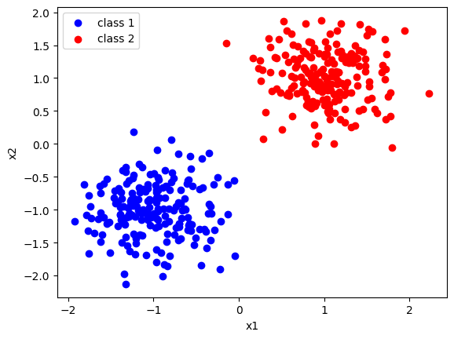

```python
for i in range(len(data)):
    if data['y'][i] == 1:
        plt_class1 = plt.scatter(data['x1'][i], data['x2'][i], c='b', label="class 1")
    else:
        plt_class2 = plt.scatter(data['x1'][i], data['x2'][i], c='r', label="class 2")
plt.xlabel("x1")
plt.ylabel("x2")
plt.legend(handles=[plt_class1, plt_class2])
```

یک نورون را با استفاده از قاعده آموزش پرسپترون (با مقدار ترشلد دلخواه) آموزش دهید، سپس با استفاده از داده‌های مربوط به تست نورون را تست کنید، همچنین دو خط موازی جدا کننده برای آستانه در نورون پرسپترون مشخص کنید، و در نهایت scatter plot مربوط به تست داده‌ها با شبکه پرسپترون آموزش دیده را به همراه خطوط جدا کننده پرسپترون نشان دهید.

```python
lr =  0.1
theta = 0.5
weights, bias = np.zeros(2), 0

for i in range(len(x1_train)):
    if OutputResponse(net_input(np.array([x1_train[i], x2_train[i]]), weights, bias), theta) != y_train[i]:
        weights[0] = updateWeights(x1_train[i], weights[0], lr, y_train[i])
        weights[1] = updateWeights(x2_train[i], weights[1], lr, y_train[i])
        bias = updateBias(bias, lr, y_train[i])
```

```
============= Test Data ============
===   label    ======= Predicted ===
===  class 1   =======  class 1  ===
===  class 2   =======  class 2  ===
===  class 1   =======  class 1  ===
===  class 2   =======  class 2  ===
===  class 2   =======  class 2  ===
===  class 2   =======  class 2  ===
===  class 2   =======  class 2  ===
===  class 1   =======  class 1  ===
===  class 2   =======  class 2  ===
===  class 2   =======  class 2  ===
===  class 2   =======  class 2  ===
===  class 2   =======  class 2  ===
===  class 1   =======  class 1  ===
===  class 1   =======  class 1  ===
===  class 1   =======  class 1  ===
===  class 2   =======  class 2  ===
===  class 2   =======  class 2  ===
===  class 1   =======  class 1  ===
===  class 2   =======  class 2  ===
===  class 1   =======  class 1  ===
===  class 1   =======  class 1  ===
===  class 1   =======  class 1  ===
===  class 2   =======  class 2  ===
===  class 1   =======  class 1  ===
===  class 2   =======  class 2  ===
===  class 1   =======  class 1  ===
===  class 1   =======  class 1  ===
===  class 1   =======  class 1  ===
===  class 2   =======  class 2  ===
===  class 2   =======  class 2  ===
===  class 2   =======  class 2  ===
===  class 1   =======  class 1  ===
===  class 1   =======  class 1  ===
===  class 2   =======  class 2  ===
===  class 1   =======  class 1  ===
===  class 2   =======  class 2  ===
===  class 2   =======  class 2  ===
===  class 2   =======  class 2  ===
```

[output cut: 48 more lines]

```
===  class 1   =======  class 1  ===
===  class 1   =======  class 1  ===
===  class 1   =======  class 1  ===
===  class 1   =======  class 1  ===
===  class 1   =======  class 1  ===
===  class 1   =======  class 1  ===
===  class 1   =======  class 1  ===
===  class 2   =======  class 2  ===
===  class 1   =======  class 1  ===
===  class 2   =======  class 2  ===
===  class 2   =======  class 2  ===
===  class 2   =======  class 2  ===
===  class 1   =======  class 1  ===
===  class 2   =======  class 2  ===
====================================
```

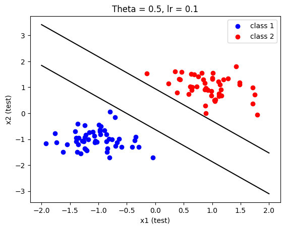

```python
print("============= Test Data ============")
print("===   label    ======= Predicted ===")
predicted_values = []
for i in range(len(x1_test)):
    predicted_values.append(OutputResponse(net_input(np.array([x1_test[i], x2_test[i]]), weights, bias), theta))
    if y_test[i] == 1:
        flag = "class 1"
    else:
        flag = "class 2"

    if predicted_values[i] == 1:
        flag2 = "class 1"
    else:
        flag2 = "class 2"

    print("===  " + flag + "   =======  " + flag2 + "  ===")
    if y_test[i] == 1:
        plt_class1 = plt.scatter(x1_test[i], x2_test[i], c='b', label="class 1")
    else:
        plt_class2 = plt.scatter(x1_test[i], x2_test[i], c='r', label="class 2")
print("====================================")

x1, x2 = -2, 2
plt.plot([x1, x2], [-(weights[0]/weights[1]) * x1 - (bias/weights[1]) + (theta/weights[1]), -(weights[0]/weights[1]) * x2 - (bias/weights[1]) + theta/weights[1]], 'black')
plt.plot([x1, x2], [-(weights[0]/weights[1]) * x1 - (bias/weights[1]) - (theta/weights[1]), -(weights[0]/weights[1]) * x2 - (bias/weights[1]) - theta/weights[1]], 'black')
plt.xlabel("x1 (test)")
plt.ylabel("x2 (test)")
plt.title("Theta = 0.5, lr = 0.1")
plt.legend(handles=[plt_class1, plt_class2])
```

با مقدار آستانه متفاوت با بخش قبل، دوباره قسمت قبلی را تکرار کنید و بیان کنید مقدار متفاوت ترشلد در آموزش نورون پرسپترون چه تاثیری دارد.

```
======= Test Data (theta = 0) =======
===   label    ======= Predicted ===
===  class 1   =======  class 1  ===
===  class 2   =======  class 2  ===
===  class 1   =======  class 1  ===
===  class 2   =======  class 2  ===
===  class 2   =======  class 2  ===
===  class 2   =======  class 2  ===
===  class 2   =======  class 2  ===
===  class 1   =======  class 1  ===
===  class 2   =======  class 2  ===
===  class 2   =======  class 2  ===
===  class 2   =======  class 2  ===
===  class 2   =======  class 2  ===
===  class 1   =======  class 1  ===
===  class 1   =======  class 1  ===
===  class 1   =======  class 1  ===
===  class 2   =======  class 2  ===
===  class 2   =======  class 2  ===
===  class 1   =======  class 1  ===
===  class 2   =======  class 2  ===
===  class 1   =======  class 1  ===
===  class 1   =======  class 1  ===
===  class 1   =======  class 1  ===
===  class 2   =======  class 2  ===
===  class 1   =======  class 1  ===
===  class 2   =======  class 2  ===
===  class 1   =======  class 1  ===
===  class 1   =======  class 1  ===
===  class 1   =======  class 1  ===
===  class 2   =======  class 2  ===
===  class 2   =======  class 2  ===
===  class 2   =======  class 2  ===
===  class 1   =======  class 1  ===
===  class 1   =======  class 1  ===
===  class 2   =======  class 2  ===
===  class 1   =======  class 1  ===
===  class 2   =======  class 2  ===
===  class 2   =======  class 2  ===
===  class 2   =======  class 2  ===
```

[output cut: 568 more lines]

```
===  class 1   =======  class 1  ===
===  class 1   =======  class 1  ===
===  class 1   =======  class 1  ===
===  class 1   =======  class 1  ===
===  class 1   =======  class 1  ===
===  class 1   =======  class 1  ===
===  class 1   =======  class 1  ===
===  class 2   =======  class 2  ===
===  class 1   =======  class 1  ===
===  class 2   =======  class 2  ===
===  class 2   =======  class 2  ===
===  class 2   =======  class 2  ===
===  class 1   =======  class 1  ===
===  class 2   =======  class 2  ===
====================================
```

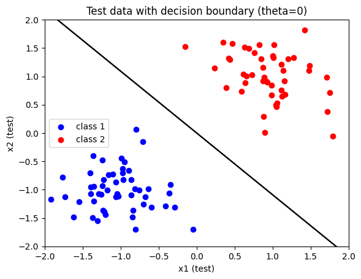

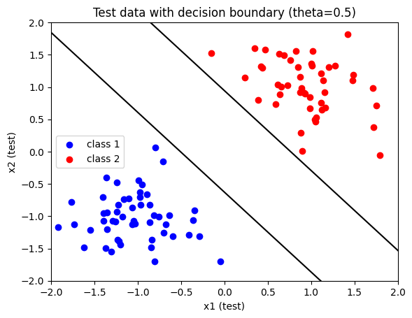

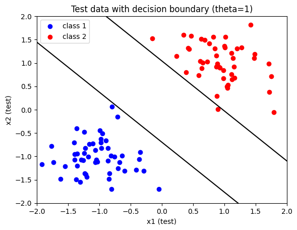

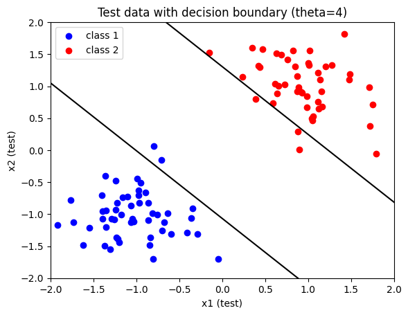

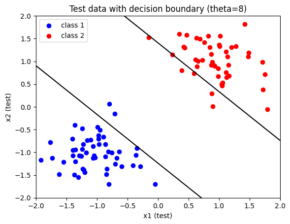

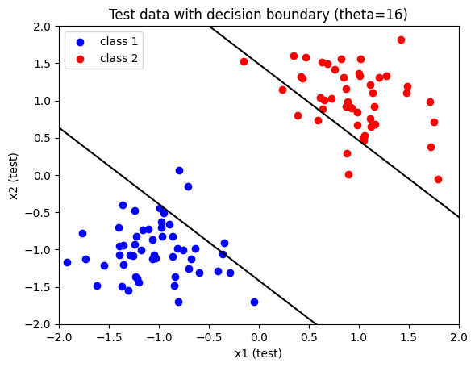

```python
lr =  0.1
theta = [0, 0.5, 1, 4, 8, 16]

for th in theta:
    weights, bias = np.zeros(2), 0

    for i in range(len(x1_train)):
        if OutputResponse(net_input(np.array([x1_train[i], x2_train[i]]), weights, bias), th) != y_train[i]:
            weights[0] = updateWeights(x1_train[i], weights[0], lr, y_train[i])
            weights[1] = updateWeights(x2_train[i], weights[1], lr, y_train[i])
            bias = updateBias(bias, lr, y_train[i])

    plt.figure()
    print("======= Test Data (theta = {}) =======".format(th))
    print("===   label    ======= Predicted ===")
    predicted_values = []
    for i in range(len(x1_test)):
        predicted_values.append(OutputResponse(net_input(np.array([x1_test[i], x2_test[i]]), weights, bias), th))
        if y_test[i] == 1:
            flag = "class 1"
        else:
            flag = "class 2"

        if predicted_values[i] == 1:
            flag2 = "class 1"
        elif  predicted_values[i] == 0:
            flag2 = "   ?   "
        else:
            flag2 = "class 2"

        print("===  " + flag + "   =======  " + flag2 + "  ===")
        if y_test[i] == 1:
            plt_class1 = plt.scatter(x1_test[i], x2_test[i], c='b', label="class 1")
        else:
            plt_class2 = plt.scatter(x1_test[i], x2_test[i], c='r', label="class 2")
    print("====================================\n")

    x1, x2 = -2, 2
    plt.plot([x1, x2], [-(weights[0]/weights[1]) * x1 - (bias/weights[1]) + (th/weights[1]), -(weights[0]/weights[1]) * x2 - (bias/weights[1]) + th/weights[1]], 'black')
    plt.plot([x1, x2], [-(weights[0]/weights[1]) * x1 - (bias/weights[1]) - (th/weights[1]), -(weights[0]/weights[1]) * x2 - (bias/weights[1]) - th/weights[1]], 'black')
    plt.xlabel("x1 (test)")
    plt.ylabel("x2 (test)")
    plt.xlim([-2, 2])
    plt.ylim([-2, 2])
    plt.title("Test data with decision boundary (theta={})".format(th))
    plt.legend(handles=[plt_class1, plt_class2])
```

در این قسمت lr را مانند قسمت قبل 0.1 در نظر گرفتم و با افزایش آستانه انتظار دارم که dicision boundry ما افزایش پیدا بکند یعنی فاصله خطوط جداکننده از یکدیگر بیشتر شود. و مشاهده می‌شود که با تغییر theta از 0.5 تا 16 به همین نتیجه رسیدیم. داده‌های تستی که در ناحیه بین دو خط جداکننده قرار می‌گیرند، با توجه به اینکه activation function ما تابع sign است، در خروجی نورون لیبل 0 خواهند داشت و نورون نتوانسته است که این ها را به خوبی کلاسبندی کند. ولی در نواحی بالا و پایین خطوط که تمرکز دو کلاس بیشتر است، مدل آن ها را به درستی تشخیص داده و لیبل درست میزند. * مقادیری که با ? نشان داده شده‌اند، مقادیری است که برای خروجی نورون وقتی بعضی از داده های تست در بین دو خط جداکننده قرار گرفته اند در نظر گرفتم.

### بخش دوم: تشخیص کاراکتر با نورون پرسپترون

7 کاراکتر از حروف انگلیسی لاتین که به قدر کافی متفاوت باشند با دقت 5x7 در نظر بگیرید، هر کاراکتر را به سه فونت متفاوت در نظر بگیرید (مشابه تمرین شماره 1).

سعی کنید مساله تشخیص کاراکتر را با استفاده از قائده یادگیری پرسپترون پیاده سازی کنید، همچنین در مورد لایه ها و اجزا شبکه پرسپترون مورد استفاده توضیح دهید.

```python
chars = "NAPKSHO"
fonts_bipolar = [
                 [
                  [1,-1,-1,-1,1,
                   1,1,-1,-1,1,
                   1,-1,-1,-1,1,
                   1,-1,1,-1,1,
                   1,-1,-1,-1,1,
                   1,-1,-1,1,1,
                   1,-1,-1,-1,1], # N
                  [1,1,1,1,1,
                   1,-1,-1,-1,1,
                   1,-1,-1,-1,1,
                   1,1,1,1,1,
                   1,-1,-1,-1,1,
                   1,-1,-1,-1,1,
                   1,-1,-1,-1,1], # A
                  [1,1,1,1,1,
                   1,-1,-1,-1,1,
                   1,-1,-1,-1,1,
                   1,1,1,1,1,
                   1,-1,-1,-1,-1,
                   1,-1,-1,-1,-1,
                   1,-1,-1,-1,-1], # P
                  [1,-1,-1,-1,1,
                   1,-1,-1,1,-1,
                   1,-1,1,-1,-1,
                   1,1,-1,-1,-1,
                   1,-1,1,-1,-1,
                   1,-1,-1,1,-1,
                   1,-1,-1,-1,1], # K
                  [1,1,1,1,1,
                   1,-1,-1,-1,-1,
                   1,-1,-1,-1,-1,
                   1,1,1,1,1,
                   -1,-1,-1,-1,1,
                   -1,-1,-1,-1,1,
                   1,1,1,1,1], # S
                  [1,-1,-1,-1,1,
                   1,-1,-1,-1,1,
                   1,-1,-1,-1,1,
                   1,1,1,1,1,
                   1,-1,-1,-1,1,
                   1,-1,-1,-1,1,
                   1,-1,-1,-1,1], # H
                  [1,1,1,1,1,
                   1,-1,-1,-1,1,
                   1,-1,-1,-1,1,
                   1,-1,-1,-1,1,
                   1,-1,-1,-1,1,
                   1,-1,-1,-1,1,
                   1,1,1,1,1] # O
                 ],
                 [
                  [-1,-1,-1,1,-1,
                   1,-1,-1,-1,1,
                   1,1,-1,-1,1,
                   1,-1,1,-1,1,
                   1,-1,-1,1,1,
                   1,-1,-1,-1,1,
                   -1,1,-1,-1,-1], # N
                  [-1,-1,1,-1,-1,
                   -1,-1,1,-1,-1,
                   -1,1,-1,1,-1,
                   1,-1,-1,-1,1,
                   1,1,1,1,1,
                   1,-1,-1,-1,1,
                   1,-1,-1,-1,1], # A
                  [1,1,1,1,-1,
                   1,-1,-1,-1,1,
                   1,-1,-1,-1,1,
                   1,1,1,1,-1,
                   1,-1,-1,-1,-1,
                   1,-1,-1,-1,-1,
                   -1,1,-1,-1,-1], # P
                  [-1,1,-1,-1,1,
                   1,-1,-1,-1,1,
                   1,-1,-1,1,-1,
                   1,1,1,-1,-1,
                   1,-1,-1,1,-1,
                   1,-1,-1,-1,1,
                   -1,1,-1,-1,1], # K
                  [-1,1,1,1,-1,
                   1,-1,-1,-1,1,
                   1,-1,-1,-1,-1,
                   -1,1,1,1,-1,
                   -1,-1,-1,-1,1,
                   1,-1,-1,-1,1,
                   -1,1,1,1,-1], # S
                  [1,-1,-1,-1,1,
                   -1,1,-1,1,-1,
                   -1,1,-1,1,-1,
                   -1,1,1,1,-1,
                   -1,1,-1,1,-1,
                   -1,1,-1,1,-1,
                   1,-1,-1,-1,1], # H
                  [-1,1,1,1,-1,
                   1,-1,-1,-1,1,
                   1,-1,-1,-1,1,
                   1,-1,-1,-1,1,
                   1,-1,-1,-1,1,
                   1,-1,-1,-1,1,
                   -1,1,1,1,-1] # O
                 ],
                 [
                  [1,-1,-1,-1,1,
                   1,1,-1,-1,1,
                   1,1,1,-1,1,
                   1,1,1,1,1,
                   1,-1,1,1,1,
                   1,-1,-1,1,1,
                   1,-1,-1,-1,1], # N
                  [-1,-1,1,-1,-1,
                   -1,1,-1,1,-1,
                   1,-1,-1,-1,1,
                   1,1,1,1,1,
                   1,1,1,1,1,
                   1,-1,-1,-1,1,
                   1,-1,-1,-1,1], # A
                  [1,1,1,1,-1,
                   1,1,-1,-1,1,
                   1,1,-1,-1,1,
                   1,1,1,1,-1,
                   1,1,-1,-1,-1,
                   1,1,-1,-1,-1,
                   1,1,-1,-1,-1], # P
                  [1,1,-1,-1,1,
                   1,1,-1,1,1,
                   1,1,1,1,-1,
                   1,1,1,-1,-1,
                   1,1,1,1,-1,
                   1,1,-1,1,1,
                   1,1,-1,-1,1], # K
                  [-1,1,1,1,1,
                   1,1,-1,-1,-1,
                   1,1,1,-1,-1,
                   -1,1,1,1,-1,
                   -1,-1,1,1,1,
                   -1,-1,-1,1,1,
                   1,1,1,1,-1], # S
                  [1,-1,-1,-1,1,
                   1,-1,-1,-1,1,
                   1,1,1,1,1,
                   1,1,1,1,1,
                   1,1,1,1,1,
                   1,-1,-1,-1,1,
                   1,-1,-1,-1,1], # H
                  [-1,1,1,1,-1,
                   1,1,-1,1,1,
                   1,-1,-1,-1,1,
                   1,-1,-1,-1,1,
                   1,-1,-1,-1,1,
                   1,1,-1,1,1,
                   -1,1,1,1,-1] # O
                 ]
                ]
```

```python
# Tnitial weights and biases
numNeurons = len(chars)
weights, bias = np.zeros((numNeurons, len(fonts_bipolar[0][0]))), np.zeros((1, numNeurons))

lr =  0.1
theta = 0.5

# Train
for n in range(numNeurons):
    target = -1 * np.ones((1, numNeurons))
    target[0][n] = 1
    for font in fonts_bipolar:
        X = font
        for x in range(len(X)):
            if OutputResponse(net_input(X[x], weights[n], bias[0][n]), theta) != target[0][x]:
                weights[n] = updateWeights(X[x], weights[n], lr, target[0][x])
                bias[0][n] = updateBias(bias[0][n], lr, target[0][x])

# Test (bipolar)
Xtest = [
         [-1,-1,-1,-1,-1,
          1,-1,-1,-1,1,
          1,1,-1,-1,1,
          1,-1,1,-1,1,
          1,-1,-1,1,1,
          1,-1,-1,-1,1,
          -1,-1,-1,-1,-1],
         [-1,1,1,1,1,
          1,-1,-1,-1,-1,
          1,-1,-1,-1,1,
          1,1,1,1,1,
          1,-1,-1,-1,1,
          1,-1,-1,1,1,
          -1,-1,-1,-1,1],
         [1,1,1,1,1,
          1,1,-1,-1,1,
          1,-1,-1,-1,1,
          1,1,-1,1,1,
          1,-1,-1,-1,-1,
          1,-1,-1,-1,-1,
          -1,1,-1,-1,-1],
         [1,-1,-1,-1,1,
          1,-1,-1,1,1,
          1,-1,1,-1,-1,
          1,1,1,-1,-1,
          1,-1,1,-1,-1,
          1,-1,-1,1,-1,
          1,-1,-1,-1,1],
         [-1,1,1,1,1,
          1,-1,-1,-1,-1,
          1,-1,-1,-1,-1,
          1,-1,1,1,1,
          1,1,1,-1,1,
          -1,-1,-1,-1,1,
          1,1,1,1,1],
         [1,-1,-1,-1,1,
          1,-1,-1,-1,1,
          1,-1,1,-1,1,
          1,1,1,1,1,
          1,-1,-1,-1,-1,
          1,-1,-1,-1,1,
          1,-1,-1,-1,1],
         [-1,1,1,-1,1,
          1,-1,-1,-1,1,
          1,-1,-1,-1,1,
          1,-1,-1,-1,1,
          1,-1,-1,-1,1,
          1,-1,-1,1,1,
          1,1,1,1,1]
         ]

Ytest = np.zeros((1, numNeurons))

for x in range(len(Xtest)):
    for n in range(numNeurons):
        Ytest[0][n] = OutputResponse(net_input(X[x], weights[n], bias[0][n]), theta)

    # Predict
    indMax = np.argmax(Ytest[0])
    indSort = np.argsort(Ytest[0])[::-1]

    print("========================== Test Char: {} ======================".format(chars[x]))
    print("Neurons ====== Output ====== Detected? ====== Character ======")
    for n in range(numNeurons):
        print("Neuron {}:       ".format(n) + str(Ytest[0][n]) + "           {}".format("Yes" if indMax == n else " No") + "               {}".format(chars[n]))
        print("==============================================================")
    print("Predicted character: ", chars[indMax])
    print("\n")
```

```
========================== Test Char: N ======================
Neurons ====== Output ====== Detected? ====== Character ======
Neuron 0:       1.0           Yes               N
==============================================================
Neuron 1:       -1.0            No               A
==============================================================
Neuron 2:       -1.0            No               P
==============================================================
Neuron 3:       -1.0            No               K
==============================================================
Neuron 4:       -1.0            No               S
==============================================================
Neuron 5:       -1.0            No               H
==============================================================
Neuron 6:       -1.0            No               O
==============================================================
Predicted character:  N


========================== Test Char: A ======================
Neurons ====== Output ====== Detected? ====== Character ======
Neuron 0:       -1.0            No               N
==============================================================
Neuron 1:       1.0           Yes               A
==============================================================
Neuron 2:       -1.0            No               P
==============================================================
Neuron 3:       -1.0            No               K
==============================================================
Neuron 4:       -1.0            No               S
==============================================================
Neuron 5:       -1.0            No               H
==============================================================
Neuron 6:       -1.0            No               O
==============================================================
Predicted character:  A


========================== Test Char: P ======================
Neurons ====== Output ====== Detected? ====== Character ======
```

[output cut: 76 more lines]

```
Neuron 0:       -1.0            No               N
==============================================================
Neuron 1:       -1.0            No               A
==============================================================
Neuron 2:       -1.0            No               P
==============================================================
Neuron 3:       -1.0            No               K
==============================================================
Neuron 4:       -1.0            No               S
==============================================================
Neuron 5:       -1.0            No               H
==============================================================
Neuron 6:       1.0           Yes               O
==============================================================
Predicted character:  O
```

در این قسمت نیز مانند تمرین قبل، از هفت کاراکتر NAPKSHO استفاده کردم. و در ساخت فونت‌ها پیکسل‌های روشن را با لیبل 1 و پیکسل‌های خاموش را با لیبل -1 مشخص کردم. برای مدل پرسپترون نیز lr را 0.1 و مقدار آستانه را 0.5 در نظر گرفتم. از هفت نورون پرسپترون برای تشخیص کاراکتر استفاده کردم که هر یک از نورون‌ها یکی از کاراکترها را تشخیص می‌دهد. هر یک از نورون‌ها یک بردار وزن به طول کل پیکسل‌هایی که یک فونت را ساخته‌اند دارد که 7x5=35 میباشد. در هر مرحله از آموزش اگر خروجی نورون مربوطه به هر کاراکتر خروجی مدنظر و صحیح را نداشته باشد به عبارتی با لیبل‌های درست همخوانی نداشته باشد با نرخ یادگیری 0.1 آموزش داده می‌شود و خروجی اولیه آن از یک activation function که دارای مقدار آستانه 0.5 می‌باشد میگذرد. در خروجی‌های بدست آمده مشخص است که هریک از نورون‌ها به درستی عمل کرده و کاراکتر مربوط به خود را به خوبی تشخیص داده‌اند. در قسمت‌های بعدی که نرخ یادگیری را مقداری کمتر از این بخش در نظر گرفتم مشخص می‌شود برای اینکه شبکه به خوبی آموزش داده شود نیاز به epoch های بیشتری است.

در مورد تعداد ایپاک مناسب و مقدار نرخ یادگیری مناسب برای پیاده سازی این مساله توضیح دهید، آیا اضافه کردن تعداد ایپاک و کم کردن نرخ یادگیری تاثیری در آموزش نورون پرسپترون دارد؟ با نرخ های یادگیری و تعداد ایپاک‌های متفاوت شبیه سازی را انجام دهید و نتیجه را گزارش کنید.

بله قطعاً کاهش نرخ یادگیری و افزایش تعداد ایپاکها در آموزش نورون تاثیر دارد که در ادامه توضیح داده‌ام.

**With different learning rates**

```python
# Tnitial weights and biases
numNeurons = len(chars)
weights, bias = np.zeros((numNeurons, len(fonts_bipolar[0][0]))), np.zeros((1, numNeurons))

l_rs =  [0.001, 0.01, 0.1, 1]
theta = 0.5

# Test
Xtest = [
         [-1,-1,-1,-1,-1,
          1,-1,-1,-1,1,
          1,1,-1,-1,1,
          1,-1,1,-1,1,
          1,-1,-1,1,1,
          1,-1,-1,-1,1,
          -1,-1,-1,-1,-1],
         [-1,1,1,1,1,
          1,-1,-1,-1,-1,
          1,-1,-1,-1,1,
          1,1,1,1,1,
          1,-1,-1,-1,1,
          1,-1,-1,1,1,
          -1,-1,-1,-1,1],
         [1,1,1,1,1,
          1,1,-1,-1,1,
          1,-1,-1,-1,1,
          1,1,-1,1,1,
          1,-1,-1,-1,-1,
          1,-1,-1,-1,-1,
          -1,1,-1,-1,-1],
         [1,-1,-1,-1,1,
          1,-1,-1,1,1,
          1,-1,1,-1,-1,
          1,1,1,-1,-1,
          1,-1,1,-1,-1,
          1,-1,-1,1,-1,
          1,-1,-1,-1,1],
         [-1,1,1,1,1,
          1,-1,-1,-1,-1,
          1,-1,-1,-1,-1,
          1,-1,1,1,1,
          1,1,1,-1,1,
          -1,-1,-1,-1,1,
          1,1,1,1,1],
         [1,-1,-1,-1,1,
          1,-1,-1,-1,1,
          1,-1,1,-1,1,
          1,1,1,1,1,
          1,-1,-1,-1,-1,
          1,-1,-1,-1,1,
          1,-1,-1,-1,1],
         [-1,1,1,-1,1,
          1,-1,-1,-1,1,
          1,-1,-1,-1,1,
          1,-1,-1,-1,1,
          1,-1,-1,-1,1,
          1,-1,-1,1,1,
          1,1,1,1,1]
         ]

for lr in l_rs:
    print("=========================================================================")
    print("=========================== Learning rate: {} ===========================".format(lr))
    print("=========================================================================\n")
    # Train
    for n in range(numNeurons):
        target = -1 * np.ones((1, numNeurons))
        target[0][n] = 1
        for font in fonts_bipolar:
            X = font
            for x in range(len(X)):
                if OutputResponse(net_input(X[x], weights[n], bias[0][n]), theta) != target[0][x]:
                    weights[n] = updateWeights(X[x], weights[n], lr, target[0][x])
                    bias[0][n] = updateBias(bias[0][n], lr, target[0][x])
    # Test
    Ytest = np.zeros((1, numNeurons))

    for x in range(len(Xtest)):
        for n in range(numNeurons):
            Ytest[0][n] = OutputResponse(net_input(X[x], weights[n], bias[0][n]), theta)

        # Predict
        indMax = np.argmax(Ytest[0])
        indSort = np.argsort(Ytest[0])[::-1]

        print("========================== Test Char: {} ======================".format(chars[x]))
        print("Neurons ====== Output ====== Detected? ====== Character ======")
        for n in range(numNeurons):
            print("Neuron {}:       ".format(n) + str(Ytest[0][n]) + "           {}".format("Yes" if indMax == n else " No") + "               {}".format(chars[n]))
            print("==============================================================")
        print("Predicted character: ", chars[indMax])
        print("\n")
```

```
=========================================================================
=========================== Learning rate: 0.001 ===========================
=========================================================================

========================== Test Char: N ======================
Neurons ====== Output ====== Detected? ====== Character ======
Neuron 0:       0.0           Yes               N
==============================================================
Neuron 1:       0.0            No               A
==============================================================
Neuron 2:       0.0            No               P
==============================================================
Neuron 3:       0.0            No               K
==============================================================
Neuron 4:       0.0            No               S
==============================================================
Neuron 5:       0.0            No               H
==============================================================
Neuron 6:       0.0            No               O
==============================================================
Predicted character:  N


========================== Test Char: A ======================
Neurons ====== Output ====== Detected? ====== Character ======
Neuron 0:       0.0           Yes               N
==============================================================
Neuron 1:       0.0            No               A
==============================================================
Neuron 2:       0.0            No               P
==============================================================
Neuron 3:       0.0            No               K
==============================================================
Neuron 4:       0.0            No               S
==============================================================
Neuron 5:       0.0            No               H
==============================================================
Neuron 6:       0.0            No               O
==============================================================
Predicted character:  N
```

[output cut: 491 more lines]

```
Neuron 0:       -1.0            No               N
==============================================================
Neuron 1:       -1.0            No               A
==============================================================
Neuron 2:       -1.0            No               P
==============================================================
Neuron 3:       -1.0            No               K
==============================================================
Neuron 4:       -1.0            No               S
==============================================================
Neuron 5:       -1.0            No               H
==============================================================
Neuron 6:       1.0           Yes               O
==============================================================
Predicted character:  O
```

در این قسمت با نرخ های یادگیری مختلف شبکه را آموزش داده و نتایج قابل مشاهده است. در ابتدا مقدار lr را 0.001 در نظر گرفتم که همانطور که از نتایج مشخص است، شبکه نتوانسته است کاراکترها را به درستی تشخیص دهد. با افزایش lr انتظار داریم که شبکه بهتر عمل کند، چون lr در این مدل پرسپترون در واقع مانند این عمل میکند که چقدر تفاوت بین وزن‌هایی که برای کاراکترهای مختلف آموزش دیده شده‌اند ایجاد کند. و همانطور که مشاهده می‌شود با افزایش lr به 0.01 مدل توانسته 5 تا از 7 کاراکتر را به درستی تشخیص دهد. در مرحله بعد مقدار lr را به 0.1 افزایش داده و مانند بخش قبل انتظار داریم شبکه همه کاراکترها را به درستی تشخیص دهد و نتایج همین را تایید میکنند. طبیعتاً با افزایش lr به مقادیر بیشتر این اختلاف بین کاراکترها بیشتر شده. و در آخر که lr برابر با 1 در نظر گرفته شده مشاهده میشود که مدل باز هم به درستی عمل کرده است و همه 7 کاراکتر را به درستی تشخیص داده است. تاثیر lr در آموزش شبکه مشهود است و مشخص است اگر lr مقدار کمی داشته باشد به تعداد epoch های بیشتری نیاز داریم. نکته مهم این هست که اگر نرخ یادگیری را کم انتخاب کنیم و ایپاکها را افزایش دهیم وزن های نورون ها با دقت بیشتری تغییر میکنند و میتواند مقدار دقیقتری برای آنها داشت.

**With more epochs**

```python
# Tnitial weights and biases
numNeurons = len(chars)
weights, bias = np.zeros((numNeurons, len(fonts_bipolar[0][0]))), np.zeros((1, numNeurons))

lr =  0.0001
theta = 0.5

# Test
Xtest = [
         [-1,-1,-1,-1,-1,
          1,-1,-1,-1,1,
          1,1,-1,-1,1,
          1,-1,1,-1,1,
          1,-1,-1,1,1,
          1,-1,-1,-1,1,
          -1,-1,-1,-1,-1],
         [-1,1,1,1,1,
          1,-1,-1,-1,-1,
          1,-1,-1,-1,1,
          1,1,1,1,1,
          1,-1,-1,-1,1,
          1,-1,-1,1,1,
          -1,-1,-1,-1,1],
         [1,1,1,1,1,
          1,1,-1,-1,1,
          1,-1,-1,-1,1,
          1,1,-1,1,1,
          1,-1,-1,-1,-1,
          1,-1,-1,-1,-1,
          -1,1,-1,-1,-1],
         [1,-1,-1,-1,1,
          1,-1,-1,1,1,
          1,-1,1,-1,-1,
          1,1,1,-1,-1,
          1,-1,1,-1,-1,
          1,-1,-1,1,-1,
          1,-1,-1,-1,1],
         [-1,1,1,1,1,
          1,-1,-1,-1,-1,
          1,-1,-1,-1,-1,
          1,-1,1,1,1,
          1,1,1,-1,1,
          -1,-1,-1,-1,1,
          1,1,1,1,1],
         [1,-1,-1,-1,1,
          1,-1,-1,-1,1,
          1,-1,1,-1,1,
          1,1,1,1,1,
          1,-1,-1,-1,-1,
          1,-1,-1,-1,1,
          1,-1,-1,-1,1],
         [-1,1,1,-1,1,
          1,-1,-1,-1,1,
          1,-1,-1,-1,1,
          1,-1,-1,-1,1,
          1,-1,-1,-1,1,
          1,-1,-1,1,1,
          1,1,1,1,1]
         ]

epochs = [5, 35, 50, 1000]
for epoch in epochs:
    print("=========================================================================")
    print("============================= With {} epoch =============================".format(epoch))
    print("=========================================================================\n")
    for i in range(epoch):
        # Train

        for n in range(numNeurons):
            target = -1 * np.ones((1, numNeurons))
            target[0][n] = 1
            for font in fonts_bipolar:
                X = font
                for x in range(len(X)):
                    if OutputResponse(net_input(X[x], weights[n], bias[0][n]), theta) != target[0][x]:
                        weights[n] = updateWeights(X[x], weights[n], lr, target[0][x])
                        bias[0][n] = updateBias(bias[0][n], lr, target[0][x])
    # Test
    Ytest = np.zeros((1, numNeurons))

    for x in range(len(Xtest)):
        for n in range(numNeurons):
            Ytest[0][n] = OutputResponse(net_input(X[x], weights[n], bias[0][n]), theta)

        # Predict
        indMax = np.argmax(Ytest[0])
        indSort = np.argsort(Ytest[0])[::-1]

        print("========================== Test Char: {} ======================".format(chars[x]))
        print("Neurons ====== Output ====== Detected? ====== Character ======")
        for n in range(numNeurons):
            print("Neuron {}:       ".format(n) + str(Ytest[0][n]) + "           {}".format("Yes" if indMax == n else " No") + "               {}".format(chars[n]))
            print("==============================================================")
        print("Predicted character: ", chars[indMax])
        print("\n")
```

```
=========================================================================
============================= With 5 epoch =============================
=========================================================================

========================== Test Char: N ======================
Neurons ====== Output ====== Detected? ====== Character ======
Neuron 0:       0.0           Yes               N
==============================================================
Neuron 1:       0.0            No               A
==============================================================
Neuron 2:       0.0            No               P
==============================================================
Neuron 3:       0.0            No               K
==============================================================
Neuron 4:       0.0            No               S
==============================================================
Neuron 5:       0.0            No               H
==============================================================
Neuron 6:       0.0            No               O
==============================================================
Predicted character:  N


========================== Test Char: A ======================
Neurons ====== Output ====== Detected? ====== Character ======
Neuron 0:       0.0           Yes               N
==============================================================
Neuron 1:       0.0            No               A
==============================================================
Neuron 2:       0.0            No               P
==============================================================
Neuron 3:       0.0            No               K
==============================================================
Neuron 4:       0.0            No               S
==============================================================
Neuron 5:       0.0            No               H
==============================================================
Neuron 6:       0.0            No               O
==============================================================
Predicted character:  N
```

[output cut: 491 more lines]

```
Neuron 0:       -1.0            No               N
==============================================================
Neuron 1:       -1.0            No               A
==============================================================
Neuron 2:       -1.0            No               P
==============================================================
Neuron 3:       -1.0            No               K
==============================================================
Neuron 4:       -1.0            No               S
==============================================================
Neuron 5:       -1.0            No               H
==============================================================
Neuron 6:       1.0           Yes               O
==============================================================
Predicted character:  O
```

در این قسمت برای اینکه اثر تعداد epoch ها مشهود باشد نرخ یادگیری را کاهش داده و 0.0001 در نظر گرفتم. مشخص است چون نرخ یادگیری مقدار کمی دارد، شبکه برای اینکه بتواند به خوبی عمل کند نیاز دارد که تعداد epoch ها بیشتر شود. از نتایج هم مشخص است که تعداد epoch ها که افزایش پیدا کرده است مدل در تشخیص کاراکترها بهتر عمل کرده و تقریباً با هزار epoch شبکه توانسته به خوبی همه هفت کاراکتر را تشخیص بدهد.

- اگر مقدار خطا را به صورت زیر محاسبه کنیم ، آیا امکان دارد مقدار خطا در نهایت به صفر برسد، کمترین خطا بدست آمده در شبیه‌سازی خود را گزارش کنید، همچنین بیان کنید در

تشخیص چه کاراکترهایی خطای کمتری خواهیم داشت، خطای مربوط به هر کاراکتر را گزارش کنید.

[figure not shown]

```
=========================================================================
============================= With 1000 epoch =============================
=========================================================================

========================== Test Char: N ======================
Neurons ====== Output ====== Detected? ====== Character ======
Neuron 0:       1.0           Yes               N
==============================================================
Neuron 1:       -1.0            No               A
==============================================================
Neuron 2:       -1.0            No               P
==============================================================
Neuron 3:       -1.0            No               K
==============================================================
Neuron 4:       -1.0            No               S
==============================================================
Neuron 5:       -1.0            No               H
==============================================================
Neuron 6:       -1.0            No               O
==============================================================
Predicted character:  N


========================== Test Char: A ======================
Neurons ====== Output ====== Detected? ====== Character ======
Neuron 0:       -1.0            No               N
==============================================================
Neuron 1:       1.0           Yes               A
==============================================================
Neuron 2:       -1.0            No               P
==============================================================
Neuron 3:       -1.0            No               K
==============================================================
Neuron 4:       -1.0            No               S
==============================================================
Neuron 5:       -1.0            No               H
==============================================================
Neuron 6:       -1.0            No               O
==============================================================
Predicted character:  A
```

[output cut: 80 more lines]

```
Neuron 0:       -1.0            No               N
==============================================================
Neuron 1:       -1.0            No               A
==============================================================
Neuron 2:       -1.0            No               P
==============================================================
Neuron 3:       -1.0            No               K
==============================================================
Neuron 4:       -1.0            No               S
==============================================================
Neuron 5:       -1.0            No               H
==============================================================
Neuron 6:       1.0           Yes               O
==============================================================
Predicted character:  O
```

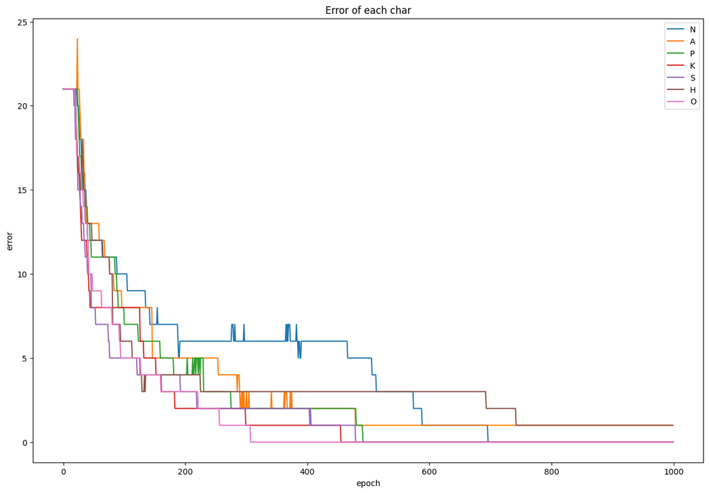

```python
# Tnitial weights and biases
numNeurons = len(chars)
weights, bias = np.zeros((numNeurons, len(fonts_bipolar[0][0]))), np.zeros((1, numNeurons))

lr =  0.0001
theta = 0.5

# Test
Xtest = [
         [-1,-1,-1,-1,-1,
          1,-1,-1,-1,1,
          1,1,-1,-1,1,
          1,-1,1,-1,1,
          1,-1,-1,1,1,
          1,-1,-1,-1,1,
          -1,-1,-1,-1,-1],
         [-1,1,1,1,1,
          1,-1,-1,-1,-1,
          1,-1,-1,-1,1,
          1,1,1,1,1,
          1,-1,-1,-1,1,
          1,-1,-1,1,1,
          -1,-1,-1,-1,1],
         [1,1,1,1,1,
          1,1,-1,-1,1,
          1,-1,-1,-1,1,
          1,1,-1,1,1,
          1,-1,-1,-1,-1,
          1,-1,-1,-1,-1,
          -1,1,-1,-1,-1],
         [1,-1,-1,-1,1,
          1,-1,-1,1,1,
          1,-1,1,-1,-1,
          1,1,1,-1,-1,
          1,-1,1,-1,-1,
          1,-1,-1,1,-1,
          1,-1,-1,-1,1],
         [-1,1,1,1,1,
          1,-1,-1,-1,-1,
          1,-1,-1,-1,-1,
          1,-1,1,1,1,
          1,1,1,-1,1,
          -1,-1,-1,-1,1,
          1,1,1,1,1],
         [1,-1,-1,-1,1,
          1,-1,-1,-1,1,
          1,-1,1,-1,1,
          1,1,1,1,1,
          1,-1,-1,-1,-1,
          1,-1,-1,-1,1,
          1,-1,-1,-1,1],
         [-1,1,1,-1,1,
          1,-1,-1,-1,1,
          1,-1,-1,-1,1,
          1,-1,-1,-1,1,
          1,-1,-1,-1,1,
          1,-1,-1,1,1,
          1,1,1,1,1]
         ]

epochs = [1000]
for epoch in epochs:
    error = np.zeros((epoch, len(chars)))
    print("=========================================================================")
    print("============================= With {} epoch =============================".format(epoch))
    print("=========================================================================\n")
    for i in range(epoch):
        # Train
        for n in range(numNeurons):
            target = -1 * np.ones((1, numNeurons))
            target[0][n] = 1
            error_tmp = np.zeros((1, len(chars)))
            for font in fonts_bipolar:
                X = font
                for x in range(len(X)):
                    if OutputResponse(net_input(X[x], weights[n], bias[0][n]), theta) != target[0][x]:
                        weights[n] = updateWeights(X[x], weights[n], lr, target[0][x])
                        bias[0][n] = updateBias(bias[0][n], lr, target[0][x])
                    error_tmp[0][n] += np.power(OutputResponse(net_input(X[x], weights[n], bias[0][n]), theta) - target[0][x], 2)
            error[i] += error_tmp[0]

    # Test
    Ytest = np.zeros((1, numNeurons))
    for x in range(len(Xtest)):
        for n in range(numNeurons):
            Ytest[0][n] = OutputResponse(net_input(X[x], weights[n], bias[0][n]), theta)

        # Predict
        indMax = np.argmax(Ytest[0])
        indSort = np.argsort(Ytest[0])[::-1]

        print("========================== Test Char: {} ======================".format(chars[x]))
        print("Neurons ====== Output ====== Detected? ====== Character ======")
        for n in range(numNeurons):
            print("Neuron {}:       ".format(n) + str(Ytest[0][n]) + "           {}".format("Yes" if indMax == n else " No") + "               {}".format(chars[n]))
            print("==============================================================")
        print("Predicted character: ", chars[indMax])
        print("\n")

# plot error
plt.figure(figsize=(15, 10))
plt.plot(error)
plt.legend(["N", "A", "P", "K", "S", "H", "O"])
plt.xlabel("epoch")
plt.ylabel("error")
plt.title("Error of each char")
```

نورون پرسپترون را با نورون هب مقایسه کنید و در صورت امکان نتایج بدست آمده از این شبیه‌سازی را با شبیه سازی مربوط به شبیه‌سازی نورون هب مقایسه کنید. (امتیازی)

در نورون هب lr و activation function نداشتیم. همچنین با توجه به نبود activation function مقداری برای آستانه نداشتیم به همین جهت فضای ما به دو قسمت تقسیم می‌شد. اما در نورون پرسپترون هم lr داریم و هم activation function که باعث می‌شود یک decision boundary داشته باشیم. دو خط جداکننده‌ای که برای نورون پرسپترون داریم باعث می‌شود نورون با دقت بیشتری دو کلاس را از هم تفکیک کند. و از نتایج به دست آمده از دو تمرین مشخص است که مدل پرسپترون خیلی بهتر از هب عمل کرده و در تشخیص کاراکترها همه را به درستی تشخیص داده است.